# Poisson Regression Model (FINAL)

J. Heffaran

2026-11-04

```r
library(dplyr)
```

```r
library(ggplot2)

set.seed(67576)
```

#NOTE TO READER: DO NOT LET THE NAME FOOL YOU, THIS IS NOT A CLEAN FILE ANYMORE. APOLOGIES. THIS FILE FOLLOWS THROUGH MY MODEL CREATION

# Section 1: Overview

## Modelling objective:

We set ourselves the challenge of predicting the Premier League final rankings for the 2025/26 season. In our group, we will each build a model to achieve this. We will then compare each of our models performance vs our own custom performance metric. We hope to accurately predict the final rankings of each team. However, we decided that good models will prioritise accuracy in predicting which teams will finish in the top 5 postitons (and hence qualify for the champions league), and the bottom three positions (and hence get relegated) come the end of the season. This desire is represented by our custom performance metric discussed in the project doecument.

## Model discussion

I designed my model under the assumption that if you can predict the number of goals which will be scored in a game between any two teams, then you will be able to simualte the entire season of fixtures in order to build a predicted table. As becomes apparent through the building of my model, this may not be the optimal approach using my methods.

A common approach discussed in the existing literature (L. Gilch & S. Müller (2018), L.F. Maya et al. (2023), Maher (1982) etc…) is to model the goals scored by each of the competing teams as independent poisson random variables whose rate parameter is the expected number of goals. In their classic 1997 paper, Dixon & Coles introduced their adjustment to this model to change the probability distribution of low scoring results.

I sought to use poisson regression with a log link function and a time-decay weighting in order to obtain the an attack and defence rating for each team in premier league. We obtained regression coefficients relating to these paramters, as well as a coefficient representing home advantage, and a baseline coefficient for our model.

I used the time weighting function
$$w(x)
= \begin{cases}
1 - \left(\dfrac{x}{c}\right)^p, & 0 \le d < c,\\
0, & d \ge c,
\end{cases}$$

where $x,c,\text{ and } p$ are parameters for representing the age of the observation, a specified cutoff, and a rate. We define $x$ relative to the most recent known date ie the date up to which we have perfect information. We use validation to obatin parameters $p$ and $c$ to be $\frac{1}{2}$ and $2555$. Thus giving us the following weighting function:

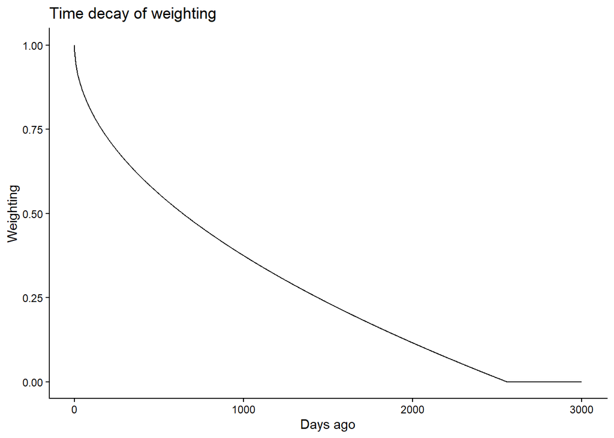

This shows the model places more importance on the most recent data, before falling off with time since.

We then modelled the expected number of goals for home team i when facing team j as:

$X_{i,j} \sim \text{Poisson}(\lambda_{i,j})$, where $\lambda_{i,j} = \exp(\psi_H + \beta + \alpha_i + \delta_j )$.

we modelled the number of goals for the away team j as:

$Y_{j,i} \sim \text{Poisson}(\mu_{j,i})$, where $\mu_{j,i} = \exp(\beta + \alpha_j + \delta_i )$.

Here $\psi_H, \beta, \alpha_i, \delta_j$ represent home advantage effect, the baseline, attack rating of team i and defence rating of team j respectivley.

We modelled the final scoreline as a joint distribution of these poisson random variables multiplied by the dixon coles adjustment:

$$f_{X,Y}(x,y) =
\frac{e^{-(\lambda_{i,j}+\mu_{j,i})}
\lambda_{i,j}^{x}\mu_{j,i}^{y}}{x!y!}
\times
\tau(x,y,\lambda_{i,j},\mu_{j,i},\rho),$$

where the correction term $\tau$ is given by:

$$\tau(x,y,\lambda,\mu,\rho)=
\begin{cases}
1-\lambda\mu\rho & \text{if } (x,y)=(0,0),\\
1+\lambda\rho & \text{if } (x,y)=(0,1),\\
1+\mu\rho & \text{if } (x,y)=(1,0),\\
1-\rho & \text{if } (x,y)=(1,1),\\
1 & \text{otherwise}.
\end{cases}$$

This raises what I expect to be the first major limitation of my modelling procedure. I used regression to estimate the team ratings according to the poisson model for goals. I then modelled games under the dixon-coles model. Now although closely related, they are not the same. If time allowed, I would look to obtain my rating coefficients via the maximisation of a custom likelihood function for the dixon-coles model.

The next difficulty I had was obtaining ratings for newly promoted teams into the premier league. As such, I took the lead from dixon-coles (1997) again, and ran the same regression on the corresponding championship seasons. Thus, we obtain ratings from the championship for teams prior to their promotion to the premier league. Now you can see the same problem arising for teams newly promoted to the championship from league 1, and then in league 1 for teams promoted from league 2 etc… I mitigated this by setting as a standard that teams promoted to championship from league 1 would have median championship ratings.

A further difficulty I had was making ratings obtained in the championship, by teams whom were then promoted, play with the ratings of teams already in the premier league. Intuitivley you would expect the ratings to not be directly transferable since its a big fish small pond to small fish big pond situation. I attempted to retain information already gathered about promoted teams by scaling their ratings by found parameters upon start of a new season.

I used the same scaling trick with different parameters to deal with teams relegated from the premier league to the championship.

## Other limitations

Like in the markets, in football prediction, I have found that past performance is always indicative of future results, apart from when it isn’t… which turns out to be often. A major limitation of my model is that it is truly dependent on past scorelines as indicator of quality. Now this is fair to some degree, but it is clearly not capturing the full picture. In a future attempt I would look to include more features in my train data. I considered playing with pm player ratings as discussed in J. Lopez Pena et al.’s 2017 paper: Plus-Minus Player Ratings for Soccer. I believed that this would allow me to form an accurate metric for measuring team strengths, while accounting for squad changes through injuries and transfers, two factors which can have dramatic impacts on team performance over short time period. I did not pursue this option to any grate depth due to it’s potential to fail dramatically.

# Section 2: Dataset generation

## Big data frame

We will use data sourced by Anna from https://football-data.co.uk/. First we look to colate our all of our train data into two dataframes: epl_all and ech_all. The pipeline for this was to source the seasons data, remove all unwanted columns, and reformat the dates to a standard.

We will source the datasets below and print their heads for your viewing pleasure:

```r
epl_all <- read.csv("https://raw.githubusercontent.com/Mathildelaunay/Sprint-1/refs/heads/main/jonty_heffaran/data/EPL_ALL.csv") %>%mutate(
  Date = as.Date(Date))

ech_all <- read.csv("https://raw.githubusercontent.com/Mathildelaunay/Sprint-1/refs/heads/main/jonty_heffaran/DATA_ECH_ALL.csv")%>%mutate(
  Date = as.Date(Date))



head(epl_all)
```

```
##     Season       Date   HomeTeam       AwayTeam FTHG FTAG
## 1 epl_1415 2014-08-16    Arsenal Crystal Palace    2    1
## 2 epl_1415 2014-08-16  Leicester        Everton    2    2
## 3 epl_1415 2014-08-16 Man United        Swansea    1    2
## 4 epl_1415 2014-08-16        QPR           Hull    0    1
## 5 epl_1415 2014-08-16      Stoke    Aston Villa    0    1
## 6 epl_1415 2014-08-16  West Brom     Sunderland    2    2
```

```r
head(ech_all)
```

```
##   X   Season       Date     HomeTeam       AwayTeam FTHG FTAG
## 1 1 ech_1415 2014-08-08    Blackburn        Cardiff    1    1
## 2 2 ech_1415 2014-08-09    Brentford       Charlton    1    1
## 3 3 ech_1415 2014-08-09     Brighton Sheffield Weds    0    1
## 4 4 ech_1415 2014-08-09        Derby      Rotherham    1    0
## 5 5 ech_1415 2014-08-09 Huddersfield    Bournemouth    0    4
## 6 6 ech_1415 2014-08-09      Ipswich         Fulham    2    1
```

## Expanding rolling windows for validation

Given our “x_all” data, we now create expanding rolling window dataframes in order to obtain our coefficients and to tune our hyper parameters. We first find dates which we can safely start and end seasons on while keeping each season disjoint. Note that this is quite important for model fitting.

We choose a season end date of July 27th and a season start date of the 28th of july. That is, each season runs from 28/07/20(yy) to 27/07/20(yy+1). For each test window, we will create two validation sets: one in which we predict the entire validation period, ie complete season prediction, and another where we predict all games after a cut-off period.

We construct the following rolling window data sets:

```r
# Important: this gives 2015/16 to 2024/25. We can then test on 2025/26.
years <- 2015:2024

# Cutoff allows us to choose when to cut validation and train data within a season.
rw_validation_sets <- generate_rolling_validation(epl_all, ech_all, years, cutoff_day = 01, cutoff_month=11)
```

We have our basic rolling window data_sets, however, we now need to convert them into a usable form in order to use them for validation. We introduce the following code to do this:

```r
# This function splits the home and away training data
def_home_away_split_train <- function(data) {
home_data <- data %>%
  transmute(Date, Team = HomeTeam, Opponent = AwayTeam, Goals = FTHG, Home = 1, obvs_weight = obvs_weight)

away_data <- data %>%
  transmute(Date, Team = AwayTeam, Opponent = HomeTeam, Goals = FTAG, Home = 0, obvs_weight = obvs_weight)

train_goal_data <- bind_rows(home_data, away_data)

return(train_goal_data)}

# This function splits the home and away validation data
# note that it does not retain the obvs weight data, this is
# needed due quirks with d_c game model
def_home_away_split_validation <- function(data) {
home_data <- data %>%
  transmute(Date, Team = HomeTeam, Opponent = AwayTeam, Goals = FTHG, Home = 1)

away_data <- data %>%
  transmute(Date, Team = AwayTeam, Opponent = HomeTeam, Goals = FTAG, Home = 0)

validation_goal_data <- bind_rows(home_data, away_data)

return(validation_goal_data)}


# This helper function pulls the teams in a comp given, we use
# it to help
get_season_teams <- function(data, year) {

  start_date <- as.Date(paste0(year, "-07-28"))
  end_date   <- as.Date(paste0(year + 1, "-07-27"))

  season_data <- data %>%
    filter(Date >= start_date, Date <= end_date)

  unique(c(
    as.character(season_data$HomeTeam),
    as.character(season_data$AwayTeam)))}

# we build this function to adjust the division ratings when
# teams move between leagues
adjust_division_ratings <- function(
    epl_ratings, ech_ratings, epl_all,
    ech_all, year, a_p, d_p, a_c, d_c,
    current_epl = NULL, current_ech = NULL) {

  # Use supplied current season teams where available.
  # Otherwise, obtain them from the historical data.
  if (is.null(current_epl)) {
    current_epl <- get_season_teams(epl_all, year)}

  if (is.null(current_ech)) {
    current_ech <- get_season_teams(ech_all, year)}

  previous_epl <- get_season_teams(epl_all, year - 1)
  previous_ech <- get_season_teams(ech_all, year - 1)


  # promoted and relegated sides
  promoted_to_epl <- intersect(current_epl, previous_ech)
  relegated_to_ech <- intersect(current_ech, previous_epl)

  # league 1 to champ
  new_ech_entrants <- setdiff(
    current_ech, union(previous_ech, previous_epl))

  # retreive ratings func to obtain the teams ratings
  get_rows <- function(teams, ratings) {
    idx <- match(teams, ratings$team_names)
    ratings[idx, , drop = FALSE]}

  # prem teams
  epl_stayers <- setdiff(current_epl, promoted_to_epl)

  epl_adjusted <- get_rows(epl_stayers, epl_ratings)

  # champ to prem teams
  promoted_ratings <- get_rows(promoted_to_epl, ech_ratings)

  promoted_ratings$att_rating <-
    promoted_ratings$att_rating * a_p

  promoted_ratings$def_rating <-
    promoted_ratings$def_rating * d_p

  epl_adjusted <- bind_rows(
    epl_adjusted, promoted_ratings)

  # champ teams
  ech_stayers <- setdiff(
    current_ech,
    c(relegated_to_ech, new_ech_entrants))

  ech_adjusted <- get_rows(ech_stayers, ech_ratings)

  # relegated to champ transfer
  relegated_ratings <- get_rows(relegated_to_ech, epl_ratings)

  relegated_ratings$att_rating <-
    relegated_ratings$att_rating * a_c

  relegated_ratings$def_rating <-
    relegated_ratings$def_rating * d_c

  ech_adjusted <- bind_rows(
    ech_adjusted, relegated_ratings)

  # new champ teams
  if (length(new_ech_entrants) > 0) {

    median_attack <- median(ech_ratings$att_rating)
    median_defence <- median(ech_ratings$def_rating)

    new_ratings <- data.frame(
      team_names = new_ech_entrants,
      att_rating = median_attack, def_rating = median_defence)

    ech_adjusted <- bind_rows(
      ech_adjusted, new_ratings)}

  # this makes sure ratings follow the current season's
  # team order.
  epl_adjusted <- epl_adjusted[
    match(current_epl, epl_adjusted$team_names),]

  ech_adjusted <- ech_adjusted[
    match(current_ech, ech_adjusted$team_names),]

  return(list(epl_ratings = epl_adjusted,
    ech_ratings = ech_adjusted,
    promoted_to_epl = promoted_to_epl,
    relegated_to_ech = relegated_to_ech,
    new_ech_entrants = new_ech_entrants))}

# We add this function to extract ratings
extract_ratings <- function(model) {

  teams <- model$xlevels$Team
  coefs <- coef(model)

  # initialise each teams log_attack rating
  attack_log <- setNames(rep(0, length(teams)), teams)
  defence_log <- setNames(rep(0, length(teams)), teams)

  # now we extract ratings
  for (team in teams) {

    attack_name <- paste0("Team", team)
    defence_name <- paste0("Opponent", team)

    if (attack_name %in% names(coefs)) {     # since baseline team
      # has no coefs,
      attack_log[team] <- coefs[attack_name]} # we only update
      # teams with coefs

    if (defence_name %in% names(coefs)) {
      defence_log[team] <- coefs[defence_name]}}

  # center the log ratings so that prem and champ ratings can be
  # scaled later
  mean_attack <- mean(attack_log)
  mean_defence <- mean(defence_log)

  ratings <- data.frame(team_names = teams,
    att_rating = exp(attack_log - mean_attack),
    def_rating = exp(defence_log - mean_defence))

  baseline <- unname(coefs["(Intercept)"]) + mean_attack +
    mean_defence
  home_advantage <- unname(coefs["Home"])

  return(list(ratings = ratings, baseline = baseline,
              home_advantage = home_advantage))}


# Okie dokie, finally we prepare our windows, and fit our
# poisson regression in order to obtain ratings.

# This func build the split training data.
prepare_training_goals <- function(data, known_date, cut_off, power) {train_data <- data %>%
    filter(Date < known_date) %>%
    mutate(days_ago = as.numeric(known_date - Date)) %>%
    filter(days_ago < cut_off) %>%
    mutate(obvs_weight = weight(days_ago, cut_off, power))
  def_home_away_split_train(train_data)}

# this function then fits our regression to the training data
fit_division_models <- function(epl_train, ech_train,
    known_date, cut_off, power) {

  # we prepare the data
  train_epl_goals <- prepare_training_goals(
    epl_train, known_date, cut_off, power)

  train_ech_goals <- prepare_training_goals(
    ech_train, known_date, cut_off, power)

  # fit our separate Poisson GLMs onto the training data
  epl_goal_model <- glm(
    Goals ~ Home + Team + Opponent,
    family = poisson(link = "log"),
    data = train_epl_goals,
    weights = obvs_weight)

  ech_goal_model <- glm(
    Goals ~ Home + Team + Opponent,
    family = poisson(link = "log"),
    data = train_ech_goals,
    weights = obvs_weight)

  # then extract our team ratings
  epl_model <- extract_ratings(epl_goal_model)
  ech_model <- extract_ratings(ech_goal_model)

  return(list(
    epl_ratings = epl_model$ratings,
    ech_ratings = ech_model$ratings,

    epl_baseline = epl_model$baseline,
    epl_home_advantage = epl_model$home_advantage,

    ech_baseline = ech_model$baseline,
    ech_home_advantage = ech_model$home_advantage,

     epl_goal_model = epl_goal_model,
     ech_goal_model = ech_goal_model))}
```

We now have our models fitted to the training data. We want to be able to evaluate our models under our Dixon-Coles game model. We want to use our fitted models ratings to then predict test fixtures under the D-C scoreline adjustment. The end goal being to vary different parameter choices and compare the accuracy of our prediction on the validation data. Note that our objective is to minimise the MAE.

```r
# First we get the code which will give the probability of
# seeing a scoreline under the dc game model
dixon_coles_probs <- function(team_ratings, home_team, away_team, baseline, home_advantage, rho = -0.05, max_goals = 7) {

  # get team ratings
  home_att <- team_ratings$att_rating[team_ratings$team_names == home_team]
  home_def <- team_ratings$def_rating[team_ratings$team_names == home_team]
  away_att <- team_ratings$att_rating[team_ratings$team_names == away_team]
  away_def <- team_ratings$def_rating[team_ratings$team_names == away_team]


  # calculate poisson rates from ratings

  lambda <- exp(baseline + home_advantage) * home_att * away_def #home rate
  mu <- exp(baseline) * away_att * home_def # away rate

  goals <- 0:max_goals #we truncate the number of goals we may
  # observe when setting a scoreline. Note that although
  # precedented, teams scoring more than max goals is very rare.
  # further we assume that if it were the case that a team scored
  # so many goals, then our model should already favour them
  # greatly since they presumably have far higher ratings than
  # their opponents.

  # get the scoreline prob under independent poisson goals
  # assumption
  probs <- outer(dpois(goals, lambda), dpois(goals, mu))

  # correction
  probs[1, 1] <- probs[1, 1] * (1 - lambda * mu * rho)
  probs[1, 2] <- probs[1, 2] * (1 + lambda * rho)
  probs[2, 1] <- probs[2, 1] * (1 + mu * rho)
  probs[2, 2] <- probs[2, 2] * (1 - rho)

  # since we truncate the scoreline grid, we normalise our
  # 'probs' so that they sum to 1.
  probs <- probs / sum(probs)

  return(probs)}

# now we introduce the code to evaluate a single fixture under our dc game model:
predict_dc_fixture <- function(home_team, away_team,
                               team_ratings, baseline,
                               home_advantage,
                               rho = -0.05, max_goals = 7) {

  # extracts the probs of results given team ratings
  probs <- dixon_coles_probs(team_ratings = team_ratings,
                             home_team = home_team,
                             away_team = away_team,
                             baseline = baseline,
                             home_advantage = home_advantage,
                             rho = rho, max_goals = max_goals)

  # expected goals under model used in model validation
  goals <- 0:(nrow(probs) - 1)

  expected_home_goals <- sum(rowSums(probs) * goals)
  expected_away_goals <- sum(colSums(probs) * goals)

  # the prob of a match outcome (used later for league table)
  prob_home_win <- sum(probs[row(probs) > col(probs)])
  prob_draw <- sum(probs[row(probs) == col(probs)])
  prob_away_win <- sum(probs[row(probs) < col(probs)])

  data.frame( expected_home_goals = expected_home_goals,
    expected_away_goals = expected_away_goals,
    prob_home_win =prob_home_win,
    prob_draw = prob_draw, prob_away_win = prob_away_win)}


# We create a callable function which will predict fixtures
# under the d_c model, given team ratings.
evaluate_dc_fixtures <- function(data, team_ratings,
    baseline, home_advantage, rho = -0.05, max_goals = 10){

  # applies to each fixture the predict_dc code
  predictions <- lapply(seq_len(nrow(data)), function(i) {

    predict_dc_fixture(home_team = data$HomeTeam[i],
      away_team = data$AwayTeam[i],
      team_ratings = team_ratings,
      baseline = baseline,
      home_advantage = home_advantage,
      rho = rho,
      max_goals = max_goals)})

  predictions <- bind_rows(predictions)

  # We then take out only the columns which we care about
  results <- bind_cols(data %>%
                         select(Date, HomeTeam, AwayTeam,
                                FTHG, FTAG), predictions)

  # Combine home and away observations
  actual <- c(results$FTHG, results$FTAG)

  predicted <- c(results$expected_home_goals,
    results$expected_away_goals)

  errors <- actual - predicted

  metrics <- data.frame(n_fixtures = nrow(data),
    n_observations = length(actual),
    mean_actual =  mean(actual), mean_predicted
    =mean(predicted),
    MAE = mean(abs(errors)), RMSE = sqrt(mean(errors^2)))

  return(list(metrics = metrics, predictions = results))}
```

Okay, we are almost at the point where we can begin to tune our parameter choices over the validation data. We will look to minimise MAE as our optimisation objective. Reiterating again that we are going to assume that an increase in the accuracy of our goal predictions will cause an increase in the accuracy of our league table by the end of the season.

We will first tune the league adjustment scalars. We will run procedure over complete season data, then again for in season data. We will aggregate the MSE and RMSE and choose the the set of scalars which result in the minimal realised values of these.

```r
# We choose our validation mode since we can either validate on
# a whole unseen season, or just complete a seen season.

validation_mode <- "complete_season"

# choose the years from which we want to produce fitted models
years <- 2015:2023

# time weight params (to be tuned seperatley later)
power <- 3
cut_off <- 730

# dc params (rho also to be tuned)
rho <- -0.05
max_goals <- 7

# we will also get the known date (note this needs to be changed if we change the season start or the in_season_cut date)

# function to get the known date variable
get_known_date <- function(year, mode) {

  if (mode == "complete_season") {
    return(as.Date(sprintf("%d-07-27", year)))}
  if (mode == "in_season") {
    return(as.Date(sprintf("%d-11-01", year)))}}

# also we will prefit the glm model to the data
prepare_rolling_models <- function(rw_validation_sets, years,
                                   mode, cut_off, power) {

  results <- lapply(years, function(year) {
    validation <-rw_validation_sets[[as.character(year)]][[mode]]

    # Use the start of the target season as the information date
    known_date <- as.Date(paste0(year, "-07-28"))

    fitted_models <- fit_division_models(
      epl_train = validation$epl_train,
      ech_train = validation$ech_train,
      known_date = known_date,
      cut_off = cut_off, power = power)

    list(year = year, known_date = known_date,
      fitted_models = fitted_models,epl_test = validation$epl_test,
      ech_test = validation$ech_test)})

  names(results) <- as.character(years)

  return(results)}

# we now create our rolling modesl. We pre-fit these since when we
# are testing our scaling params, we needn't re fit the model every
# time.

rolling_models <- prepare_rolling_models(
  rw_validation_sets = rw_validation_sets, years = years,
  mode = validation_mode, cut_off = cut_off, power = power)

# We now make code which can obtain the MSE for each term
score_dc_fixtures <- function(
    data, team_ratings, baseline, home_advantage,
    rho = -0.05,max_goals = 7) {

  # obtain predictions
  predictions <- lapply(seq_len(nrow(data)), function(i) {

  # use the predict dc function to get predictions for each fixture
  predict_dc_fixture( home_team = data$HomeTeam[i],
    away_team = data$AwayTeam[i], team_ratings = team_ratings,
    baseline = baseline, home_advantage = home_advantage,
    rho = rho, max_goals = max_goals)})

  # Collate the predictions
  predictions <- bind_rows(predictions)

  # Collect actual results
  actual <- c(data$FTHG, data$FTAG)

  predicted <- c( predictions$expected_home_goals,
                  predictions$expected_away_goals)

  # Calc errors
  errors <- actual - predicted

  return(list(n = length(errors),
    absolute_error_sum = sum(abs(errors)),
    squared_error_sum = sum(errors^2),
    MAE = mean(abs(errors)),
    RMSE = sqrt(mean(errors^2))))}
```

Okie dokie; we are finally in the position where we can find our errors in predictions under different parameters. We will do so below to compare different input parameters.

```r
evaluate_transition_parameters <- function(
    a_p, d_p, a_c, d_c,
    rolling_models,
    epl_all,
    ech_all,
    rho = -0.05,
    max_goals = 5) {

  yearly_results <- lapply(rolling_models, function(validation) {

    year <- validation$year
    fitted <- validation$fitted_models

    # apply the adjustments
    adjusted <- adjust_division_ratings(
      epl_ratings = fitted$epl_ratings,
      ech_ratings = fitted$ech_ratings,
      epl_all = epl_all, ech_all = ech_all,
      year = year, a_p = a_p, d_p = d_p,
      a_c = a_c, d_c = d_c)

    # eval prem results
    epl_score <- score_dc_fixtures(
      data = validation$epl_test,
      team_ratings = adjusted$epl_ratings,
      baseline = fitted$epl_baseline,
      home_advantage = fitted$epl_home_advantage,
      rho = rho, max_goals = max_goals)

    # evaluate champ predictions
    ech_score <- score_dc_fixtures(
      data = validation$ech_test,
      team_ratings = adjusted$ech_ratings,
      baseline = fitted$ech_baseline,
      home_advantage = fitted$ech_home_advantage, rho = rho,
      max_goals = max_goals)

    # combine the scores over seasons
    total_n <- epl_score$n + ech_score$n

    total_abs <- epl_score$absolute_error_sum +
      ech_score$absolute_error_sum

    total_sq <- epl_score$squared_error_sum +
      ech_score$squared_error_sum

    data.frame( year = year, EPL_MAE = epl_score$MAE,
      EPL_RMSE = epl_score$RMSE, ECH_MAE = ech_score$MAE,
      ECH_RMSE = ech_score$RMSE,
      Combined_MAE = total_abs / total_n,
      Combined_RMSE = sqrt(total_sq / total_n),
      n_observations = total_n, absolute_error_sum = total_abs,
      squared_error_sum = total_sq)})

  yearly_results <- bind_rows(yearly_results)

  # overall results
  total_n <- sum(yearly_results$n_observations)
  total_abs <- sum(yearly_results$absolute_error_sum)
  total_sq <- sum(yearly_results$squared_error_sum)

  summary <- data.frame(
    a_p = a_p, d_p = d_p, a_c = a_c, d_c = d_c,
    Mean_EPL_MAE = mean(yearly_results$EPL_MAE),
    Mean_ECH_MAE = mean(yearly_results$ECH_MAE),
    Mean_Combined_MAE = mean(yearly_results$Combined_MAE),
    Pooled_Combined_MAE = total_abs / total_n,
    Pooled_Combined_RMSE = sqrt(total_sq / total_n),
    SD_Combined_MAE = sd(yearly_results$Combined_MAE))

  return(list(summary = summary, yearly_results = yearly_results))}
```

We now define our parameter grid. Note this grid is very coarse. we may be able to refine this later given a ball park. We start with such a small grid since our current process is computationally murderous in the current setup (apologies), im going to impose that champ team ratings can only get worse going to prem. I will make no restriction on prem to champ since back to back relegations are not unheard of however back to back top finishes over leagues is uncommon to the point of non-existent.

We will not run the following code since it takes ages to knit. We will however source the results table for your viewing pleasure.

```r
results <- read.csv("https://raw.githubusercontent.com/Mathildelaunay/Sprint-1/refs/heads/main/jonty_heffaran/data/top_10_transition_results.csv")

print(head(results))
```

```
##   Rank a_p d_p a_c d_c Mean_EPL_MAE Mean_ECH_MAE Mean_Combined_MAE
## 1    1 0.8 1.2 1.2 0.8       0.9525       0.8947            0.9183
## 2    2 0.8 1.1 1.2 0.8       0.9550       0.8947            0.9193
## 3    3 0.8 1.2 1.0 0.8       0.9525       0.8989            0.9208
## 4    4 0.8 1.0 1.2 0.8       0.9589       0.8947            0.9209
## 5    5 0.9 1.2 1.2 0.8       0.9605       0.8947            0.9215
## 6    6 0.8 1.1 1.0 0.8       0.9550       0.8989            0.9218
##   Pooled_Combined_RMSE
## 1               1.1739
## 2               1.1764
## 3               1.1793
## 4               1.1795
## 5               1.1766
## 6               1.1817
```

The initial tune suggests that 0.8,1.2,1.2,0.8 result in smallest mean combined MAE. Since these are the extreme points of the trialed grids, we will attempt now change our grid values and re-run our test. We will now tune the championship to prem params keeping prem to champ ones fixed in order to decrease compute time. We will actually execute this code.

```r
parameter_grid <- expand.grid(
  a_p = c(0.7,0.8,0.9),
  d_p = c(1.1, 1.2, 1,3),
  a_c = c(1.2),
  d_c = c(0.8))

tuning_results_ch_to_prem <- lapply(seq_len(nrow(parameter_grid)), function(i) {
  params <- parameter_grid[i, ]
  result <- evaluate_transition_parameters(
    a_p = params$a_p, d_p = params$d_p,
    a_c = params$a_c, d_c = params$d_c,
    rolling_models = rolling_models,
    epl_all = epl_all,
    ech_all = ech_all,
    rho = rho, max_goals = max_goals)
  result$summary})

tuning_results_ch_to_prem <- bind_rows(tuning_results_ch_to_prem) %>%arrange(Mean_Combined_MAE) %>%mutate(Rank = row_number())

print(tuning_results_ch_to_prem)
```

```
##    a_p d_p a_c d_c Mean_EPL_MAE Mean_ECH_MAE Mean_Combined_MAE
## 1  0.7 1.2 1.2 0.8    0.9463376    0.8945734         0.9156790
## 2  0.7 1.1 1.2 0.8    0.9489402    0.8945734         0.9167401
## 3  0.8 1.2 1.2 0.8    0.9521329    0.8945734         0.9180418
## 4  0.7 1.0 1.2 0.8    0.9529590    0.8945734         0.9183787
## 5  0.8 1.1 1.2 0.8    0.9546171    0.8945734         0.9190547
## 6  0.8 1.0 1.2 0.8    0.9585383    0.8945734         0.9206535
## 7  0.9 1.2 1.2 0.8    0.9600267    0.8945734         0.9212603
## 8  0.9 1.1 1.2 0.8    0.9622495    0.8945734         0.9221666
## 9  0.9 1.0 1.2 0.8    0.9660124    0.8945734         0.9237009
## 10 0.7 3.0 1.2 0.8    1.0377387    0.8945734         0.9529455
## 11 0.8 3.0 1.2 0.8    1.0473687    0.8945734         0.9568719
## 12 0.9 3.0 1.2 0.8    1.0586153    0.8945734         0.9614574
##    Pooled_Combined_MAE Pooled_Combined_RMSE SD_Combined_MAE Rank
## 1            0.9156790             1.172326      0.01849589    1
## 2            0.9167401             1.174868      0.01909558    2
## 3            0.9180418             1.173691      0.01814607    3
## 4            0.9183787             1.178084      0.01972835    4
## 5            0.9190547             1.176173      0.01873456    5
## 6            0.9206535             1.179342      0.01935824    6
## 7            0.9212603             1.176342      0.01786713    7
## 8            0.9221666             1.178742      0.01842873    8
## 9            0.9237009             1.181843      0.01904508    9
## 10           0.9529455             1.220239      0.02585569   10
## 11           0.9568719             1.224112      0.02618867   11
## 12           0.9614574             1.229424      0.02651217   12
```

This gives lowest combined MSE at 0.7,1.2,1.2,0.8. We will now run same procedure fixing the Championship parameters:

```r
parameter_grid <- expand.grid(
  a_p = c(0.7),
  d_p = c(1.2),
  a_c = c(1.1, 1.2, 1.3),
  d_c = c(0.8, 0.7, 0.9))

tuning_results_ch_to_prem <- lapply(seq_len(nrow(parameter_grid)), function(i) {
  params <- parameter_grid[i, ]
  result <- evaluate_transition_parameters(
    a_p = params$a_p, d_p = params$d_p,
    a_c = params$a_c, d_c = params$d_c,
    rolling_models = rolling_models,
    epl_all = epl_all,
    ech_all = ech_all,
    rho = rho, max_goals = max_goals)
  result$summary})

tuning_results_ch_to_prem <- bind_rows(tuning_results_ch_to_prem) %>%arrange(Mean_Combined_MAE) %>%mutate(Rank = row_number())

print(tuning_results_ch_to_prem)
```

```
##   a_p d_p a_c d_c Mean_EPL_MAE Mean_ECH_MAE Mean_Combined_MAE
## 1 0.7 1.2 1.3 0.7    0.9463376    0.8894366         0.9126365
## 2 0.7 1.2 1.2 0.7    0.9463376    0.8903091         0.9131533
## 3 0.7 1.2 1.1 0.7    0.9463376    0.8920358         0.9141760
## 4 0.7 1.2 1.3 0.8    0.9463376    0.8938429         0.9152463
## 5 0.7 1.2 1.2 0.8    0.9463376    0.8945734         0.9156790
## 6 0.7 1.2 1.1 0.8    0.9463376    0.8961769         0.9166287
## 7 0.7 1.2 1.3 0.9    0.9463376    0.9000098         0.9188988
## 8 0.7 1.2 1.2 0.9    0.9463376    0.9006258         0.9192637
## 9 0.7 1.2 1.1 0.9    0.9463376    0.9020897         0.9201307
##   Pooled_Combined_MAE Pooled_Combined_RMSE SD_Combined_MAE Rank
## 1           0.9126365             1.169659      0.01778898    1
## 2           0.9131533             1.171536      0.01786643    2
## 3           0.9141760             1.173993      0.01794463    3
## 4           0.9152463             1.170511      0.01840785    4
## 5           0.9156790             1.172326      0.01849589    5
## 6           0.9166287             1.174732      0.01851161    6
## 7           0.9188988             1.172920      0.01925475    7
## 8           0.9192637             1.174653      0.01934088    8
## 9           0.9201307             1.176988      0.01935690    9
```

Okay, the best results are given by .7, 1.2, 1.3, .7. Now these are the extreme values of grid so we will rerun the test to see if we can improve these results.

```r
parameter_grid <- expand.grid(
  a_p = c(0.7),
  d_p = c(1.2),
  a_c = c(1.3, 1.4, 1.5),
  d_c = c(0.7, 0.6, 0.5))

tuning_results_ch_to_prem <- lapply(seq_len(nrow(parameter_grid)), function(i) {
  params <- parameter_grid[i, ]
  result <- evaluate_transition_parameters(
    a_p = params$a_p, d_p = params$d_p,
    a_c = params$a_c, d_c = params$d_c,
    rolling_models = rolling_models,
    epl_all = epl_all,
    ech_all = ech_all,
    rho = rho, max_goals = max_goals)
  result$summary})

tuning_results_ch_to_prem <- bind_rows(tuning_results_ch_to_prem) %>%arrange(Mean_Combined_MAE) %>%mutate(Rank = row_number())

print(tuning_results_ch_to_prem)
```

```
##   a_p d_p a_c d_c Mean_EPL_MAE Mean_ECH_MAE Mean_Combined_MAE
## 1 0.7 1.2 1.4 0.6    0.9463376    0.8878358         0.9116884
## 2 0.7 1.2 1.3 0.6    0.9463376    0.8880319         0.9118046
## 3 0.7 1.2 1.5 0.6    0.9463376    0.8881979         0.9119029
## 4 0.7 1.2 1.4 0.7    0.9463376    0.8893721         0.9125983
## 5 0.7 1.2 1.3 0.7    0.9463376    0.8894366         0.9126365
## 6 0.7 1.2 1.5 0.7    0.9463376    0.8898749         0.9128962
## 7 0.7 1.2 1.4 0.5    0.9463376    0.8900103         0.9129764
## 8 0.7 1.2 1.5 0.5    0.9463376    0.8902379         0.9131112
## 9 0.7 1.2 1.3 0.5    0.9463376    0.8903412         0.9131723
##   Pooled_Combined_MAE Pooled_Combined_RMSE SD_Combined_MAE Rank
## 1           0.9116884             1.169033      0.01743538    1
## 2           0.9118046             1.170381      0.01756627    2
## 3           0.9119029             1.168251      0.01745955    3
## 4           0.9125983             1.168361      0.01770230    4
## 5           0.9126365             1.169659      0.01778898    5
## 6           0.9128962             1.167640      0.01771848    6
## 7           0.9129764             1.171307      0.01769858    7
## 8           0.9131112             1.170488      0.01765790    8
## 9           0.9131723             1.172684      0.01785258    9
```

Okay, best results are .7, 1.2, 1.4, .6. Neither of these are extreme points so we are happy this is the optimal set of parameters given our level of granularity.

This gives us our optimal parameters for ap,dp,ac,dc = .7, 1.2, 1.4, .6. We can now fix these and tune our cut_off date and weighting power.

# Tuning power and cut_off

For ease we will use a rho value of -0.13 as found in the blog https://opisthokonta.net/?p=890. We may look to find our own parameter value if the time constraints allow, but for now this will suffice. We do, however, need to tune the power and cut_off parameters for our time weighting functions. We will use a coarse grid initially for this which we may refine if time allows.

Again, this takes a rather long time to run. Hence, we will just call the results.

We get the following summary

```r
print(head(read.csv("https://raw.githubusercontent.com/Mathildelaunay/Sprint-1/refs/heads/main/jonty_heffaran/Weight%20optim%20summary.csv")))
```

```
##   Rank power cut_off Mean_EPL_MAE Mean_ECH_MAE Pooled_Combined_MAE
## 1    1   0.5    2555    0.9384732    0.8870959           0.9080437
## 2    2   0.5    2190    0.9387249    0.8870273           0.9081057
## 3    3   1.0    2190    0.9388654    0.8872460           0.9082926
## 4    4   1.0    2555    0.9387744    0.8874058           0.9083501
## 5    5   0.5    1825    0.9393151    0.8872950           0.9085049
## 6    6   1.0    1825    0.9392847    0.8873206           0.9085077
##   Pooled_Combined_RMSE SD_Combined_MAE
## 1             1.163742      0.01622099
## 2             1.163877      0.01628475
## 3             1.164070      0.01642612
## 4             1.164010      0.01630262
## 5             1.164312      0.01635756
## 6             1.164266      0.01655143
```

Our lowest combined MAE is given when we use power = 0.5 and cut_off = 2555. If we plot this weighting curve it gives:

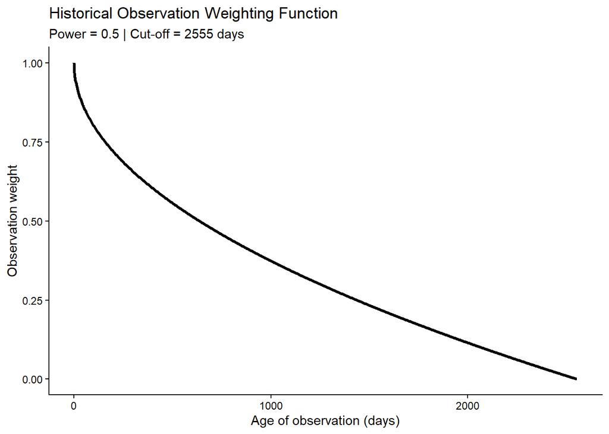

```r
power <- 0.5
cut_off <- 2555

weighting_data <- data.frame(
  days_ago = seq(0, cut_off, length.out = 1000)) %>%
  mutate(weight = ifelse(
      days_ago >= cut_off,0,1 - (days_ago / cut_off)^power))

ggplot(weighting_data, aes(x = days_ago, y = weight)) +
  geom_line(linewidth = 1.2) +
  labs(
    title = "Historical Observation Weighting Function",
    subtitle = "Power = 0.5 | Cut-off = 2555 days",
    x = "Age of observation (days)",
    y = "Observation weight"
  ) + scale_y_continuous(limits = c(0, 1)) + theme_classic()
```

This is contrary to my prior that the best weighting curve would be concave. We will use these parameters in our final model.

We have now obtained all of our chosen parameters. We can look to fit our model now.

# Section 3: Fitting the poisson regression

We fix our model parameters and then fit our model given these.

```r
known_date <- as.Date("2025-07-28")
# fit the models under params
final_models <- fit_division_models(
  epl_train = epl_all, ech_train = ech_all,
  known_date = known_date, cut_off = 2555, power = 0.5)

current_epl <- unique(c(epl_test$HomeTeam, epl_test$AwayTeam))
current_ech <- unique(c(ech_test$HomeTeam, ech_test$AwayTeam))

final_ratings <- adjust_division_ratings(
  epl_ratings = final_models$epl_ratings,
  ech_ratings = final_models$ech_ratings,
  epl_all = epl_all,
  ech_all = ech_all,
  year = 2025,
  a_p = 0.7,
  d_p = 1.2,
  a_c = 1.4,
  d_c = 0.6,
  current_epl = current_epl,
  current_ech = current_ech
)
```

# Section 4: Testing our model

```r
epl_tables <- compare_league_tables(
  fixtures = epl_test,
  predictions = epl_predictions)
# we'll have a look of course we'll have a look.
print(epl_tables$comparison)
```

```
## # A tibble: 20 × 17
##    Team           P_Predicted Expected_Pts Expected_GF Expected_GA Expected_GD
##    <chr>                <dbl>        <dbl>       <dbl>       <dbl>       <dbl>
##  1 Arsenal                 38         71.2        67.7        38.2      29.4
##  2 Man City                38         79.1        79.2        35.9      43.3
##  3 Man United              38         50.2        49.9        52.5      -2.53
##  4 Aston Villa             38         51.9        53.4        53.6      -0.183
##  5 Liverpool               38         73.8        75.3        40.8      34.6
##  6 Bournemouth             38         43.6        46.5        59.6     -13.1
##  7 Sunderland              38         29.0        30.4        65.1     -34.6
##  8 Brighton                38         49.2        51.9        56.4      -4.49
##  9 Brentford               38         50.0        53.7        56.9      -3.26
## 10 Chelsea                 38         58.2        57.4        47.9       9.51
## 11 Fulham                  38         45.5        46.8        56.5      -9.72
## 12 Newcastle               38         56.6        59.6        52.7       6.91
## 13 Everton                 38         41.0        37.2        52.1     -14.9
## 14 Leeds                   38         52.1        47.1        46.4       0.785
## 15 Crystal Palace          38         45.6        44.7        53.8      -9.15
## 16 Nott'm Forest           38         44.2        46.4        58.3     -11.9
## 17 Tottenham               38         53.7        61.2        59.2       2.08
## 18 West Ham                38         42.8        47.2        61.8     -14.7
## 19 Burnley                 38         59.4        41.2        30.0      11.2
## 20 Wolves                  38         39.2        41.0        60.4     -19.4
## # ℹ 11 more variables: Predicted_Rank <int>, P_Actual <int>, W <int>, D <int>,
## #   L <int>, GF <int>, GA <int>, GD <int>, Pts <dbl>, Actual_Rank <int>,
## #   Rank_Difference <int>
```

We can also run our predicted table and the actual table through our performance metric to get our model score:

```r
pm <- function(predicted, actual) {

  n <- length(actual)
  # Identify the top five teams
  P5 <- which(predicted <= 5)
  A5 <- which(actual <= 5)

  # Calculate overlap between predicted and actual top five
  overlap <- length(intersect(P5, A5)) / 5

  # Identify bottom three positions
  bottom3 <- (n - 2):n

  wt <- numeric(n)

  for (i in 1:n) {

    p <- predicted[i]
    a <- actual[i]

    d <- abs(p - a)

    if (a <= 5) { # Actual position is in the top five

      if (p == a) {
        w <- 1

      } else if (p <= 5) {
        w <- overlap

      } else {
        w <- -(1 - exp(-d))
      }

    } else {# Actual position is outside the top five

      if (a %in% bottom3) {# Actual team is in the bottom three

        if (p %in% bottom3) {
          w <- 1

        } else {
          w <- -(1 - exp(-d))
        }

      } else if (p <= 5) {# Incorrectly predicted in the top five

        w <- -(1 - exp(-d))

      } else if (p == a) {# Correctly predicted outside the top five

        w <- 0.5

      } else {# Incorrectly predicted outside the top five
        k <- 0.1
        w <- -(1 - exp(-k * d))
      }
    }

    wt[i] <- w
  }

  return(sum(wt))
}
```

We then feed this into our adjusted function to give our final score:

```r
pm_adjusted <- function(predicted, actual, number_features, lambda=0.01) {

  upper <- pm(predicted = epl_tables$comparison$Actual_Rank, actual= epl_tables$comparison$Actual_Rank)

lower <- pm(predicted = 21- epl_tables$comparison$Actual_Rank,  actual= epl_tables$comparison$Actual_Rank)

  prediction_score <- (pm(predicted, actual) -lower)/ (upper - lower)

  feature_penalisation <- exp(-lambda * number_features)

  model_score <- prediction_score * feature_penalisation

  return(model_score)
}
```

Our overall score for predicting the season is given by 0.26154.

```r
pm_adjusted(predicted= epl_tables$comparison$Predicted_Rank,
            actual= epl_tables$comparison$Actual_Rank,
            number_features= 4, lambda = 0.01 )
```

```
## [1] 0.261541
```